# A Few Examples of using Markov Chain Montecarlo and The Metropolis Hastings Algorithm

Carlos C Vera Recio

4/21/2021

#### A McDonald’s manager wants to know what is the average rate of cars that pass through the drive through every day from 4pm-5pm.

#### If the manager determines that more than 15 cars pass per hour, he will need to hire a new employee.

#### He is unsure what the actual number is, but believes its somewhere between 10-20 cars

#### He brings up data from the past year, were the number of cars that pass through the drive through from 4-5pm were tallied.

#### How can we help the McDonalds employee determine this?

#### One way is by assuming the rate of cars through the drive through follows a poisson distribution.

#### We can determine the lambda, or the average rate of cars, from the poisson distribution using Markov Chain Monte Carlo and the Metropolis Hastings Algorithm

## One Dimensional MCMC example in R

##### Before using the data collected by the McDonald’s Manager, let’s try some data where we know the answer to help make sure our MCMC works

##### These are our true parameters in our simulation

```r
lambda=4
```

##### lets generate some data and see if we can determine that the lambda parameter was 4 in our simulated data

```r
# lets assume we'll collect 1000 samples
n=1000
# generate data from a poisson distribution
poisson.counts = rpois(n=n, lambda = lambda)
```

#### To perform MCMC, we need to be able to calculate the likelihood of the data given a parameter

```r
# function used to calculate the log-likelihood of a
# poisson distributed data given a lambda parameter
calc.log.lik = function(lambda)
{
  liks=dpois(x = poisson.counts,
             lambda = lambda,
             log = TRUE)
  lik=sum(liks)

  return(lik)
}
```

#### We also need to calculate the prior probability of a parameter

#### Lets assume we don’t know anything about what the true lambda is

#### We just know it’s a positive number

#### We can assign a prior distribution that gives equal probability to all positive observations

```r
prior.prob = function(prior)
{
  if(prior>0)
  {
    return(1)
  }else
  {
    return(0)
  }
}
```

#### Great! Now lets write our code for the MCMC

```r
# We'll run the MCMC for 40000 iterations
num.iters=40000

# with an initial value for lambda of (pick whatever you want)
lambda.current=20

# we'll store the lambdas in the MCMC in this vector
all.lambdas=c()

# loop for the number of iterations
for (i in 1:num.iters) {
  # get a new proposed lambda sampling
  proposal = lambda.current+rnorm(n=1, mean = 0, sd=1)

  # calculate the log likelihoods for the current and proposed lambda
  lik.current = calc.log.lik(lambda.current)
  lik.proposal = calc.log.lik(proposal)

  # calculate the prior probabilities for the parameters
  prior.current=prior.prob(lambda.current)
  prior.proposal=prior.prob(proposal)

  # calculate the log acceptance probability
  p.accept = (lik.proposal + log(prior.proposal))-(lik.current+log(prior.current))

  # accept if the log probability is larger than a random number
  rnd.num = log(runif(n=1))

  # some control flow for the possible values of p.accept
  if(is.infinite(p.accept)) # if value is infinite, move on to the next step
  {
    # do not accept lambda
    # add to list
    all.lambdas = c(all.lambdas, lambda.current)
  } else if(is.na(p.accept)) # if value is NA, move on to the next step
  {
    # do not accept lambda
    # add to list
    all.lambdas = c(all.lambdas, lambda.current)

  } else if(p.accept > rnd.num) # if p.accept is larger than random, add to list
  {
    # accept lambda
    lambda.current = proposal
    # add to list
    all.lambdas = c(all.lambdas, lambda.current)
  } else if(p.accept < rnd.num)# if p.accept is not larger than random, do not add to list
  {
    # do not accept lambda
    # add to list
    all.lambdas = c(all.lambdas, lambda.current)
  }

  # let me know if we have moved through a 1000 more iterations
  if(i %% 1000 ==0)
  {
    cat('iteration: ', i)
    cat('', sep = '\n')
  }

# end of loop
}
```

```
## iteration:  1000
## iteration:  2000
## iteration:  3000
## iteration:  4000
## iteration:  5000
## iteration:  6000
## iteration:  7000
## iteration:  8000
## iteration:  9000
## iteration:  10000
## iteration:  11000
## iteration:  12000
## iteration:  13000
## iteration:  14000
## iteration:  15000
## iteration:  16000
## iteration:  17000
## iteration:  18000
## iteration:  19000
## iteration:  20000
## iteration:  21000
## iteration:  22000
## iteration:  23000
## iteration:  24000
## iteration:  25000
## iteration:  26000
## iteration:  27000
## iteration:  28000
## iteration:  29000
## iteration:  30000
## iteration:  31000
## iteration:  32000
## iteration:  33000
## iteration:  34000
## iteration:  35000
## iteration:  36000
## iteration:  37000
## iteration:  38000
## iteration:  39000
## iteration:  40000
```

##### get the confidence interval for the estimated value of lambda

```r
quantile(x=tail(all.lambdas, n=num.iters/2), probs = c(0.025, 0.5, 0.975))
```

```
##     2.5%      50%    97.5%
## 4.028312 4.151373 4.280802
```

##### show me how the lambdas changed from begining to end

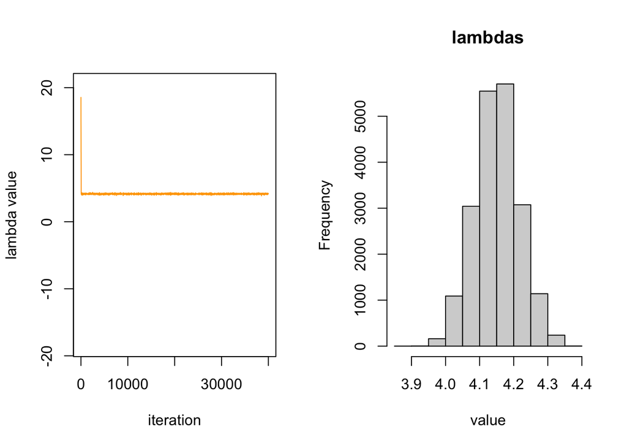

```r
par(mfrow=c(1,2))
plot(all.lambdas,
     x=1:length(all.lambdas),
     col = 'orange',
     xlab='iteration',
     ylab='lambda value',
     ylim = c(-max(all.lambdas),(max(all.lambdas)+ abs(max(lambda))/2) ),
     type='l')
hist(tail(all.lambdas, n=num.iters/2),
     main='lambdas',
     xlab = 'value')
```

#### It turns out MCMC does work!

#### There are better R packages to run MCMC

#### Lets use the fmcmc package to run MCMC in the data provided by the McDonald’s Manager

#### Lets make a histogram of the McDonald’s counts

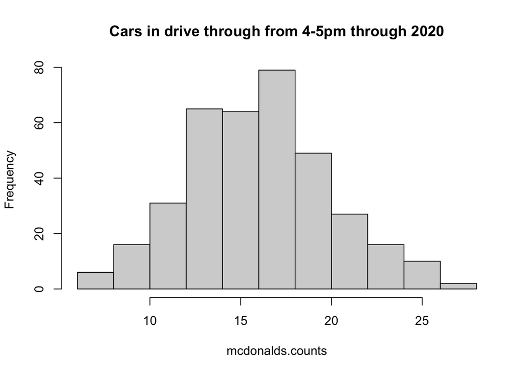

```r
hist(mcdonalds.counts, main = 'Cars in drive through from 4-5pm through 2020')
```

#### As before, we still have to define the likelihood function

```r
calc.log.lik = function(lambda)
{
  liks=dpois(x = mcdonalds.counts,
             lambda = lambda,
             log = TRUE)
  lik=sum(liks)

  return(lik)
}
```

#### this is the code to run the MCMC function in fmcmc

```r
# load library
library(fmcmc)

# fmcmc command
ans <-
  MCMC(
  fun=calc.log.lik,
  initial = c(lambda=10),
  nsteps = 1e5,
  kernel = kernel_normal_reflective(scale = .1, ub = 25, lb = 5),
  burnin = 20000
  )

# show answer
summary(ans)
```

```
##
## Iterations = 20001:1e+05
## Thinning interval = 1
## Number of chains = 1
## Sample size per chain = 80000
##
## 1. Empirical mean and standard deviation for each variable,
##    plus standard error of the mean:
##
##           Mean             SD       Naive SE Time-series SE
##      1.651e+01      2.129e-01      7.527e-04      3.738e-03
##
## 2. Quantiles for each variable:
##
##  2.5%   25%   50%   75% 97.5%
## 16.09 16.37 16.51 16.65 16.93
```

#### The fmcmc package also allows for easy visualization of the

#### trace plots and density plots for your estimated parameter

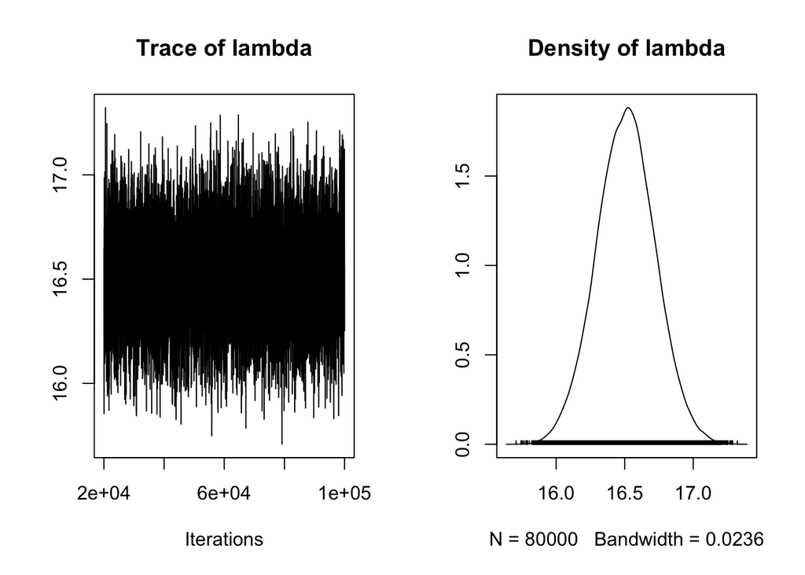

```r
plot(ans)
```

### Since the lambda parameter is significantly larger than 15 (95% CI > 15),

### It seems that the McDonald’s Manager has some hiring to do!

## Example of MCMC to estimate two parameters

#### Two basketball players chose their favorite 5 spots from the court (each) and shoot 30 shots from each spot.

#### This is a distribution of how many shots they made from each spot

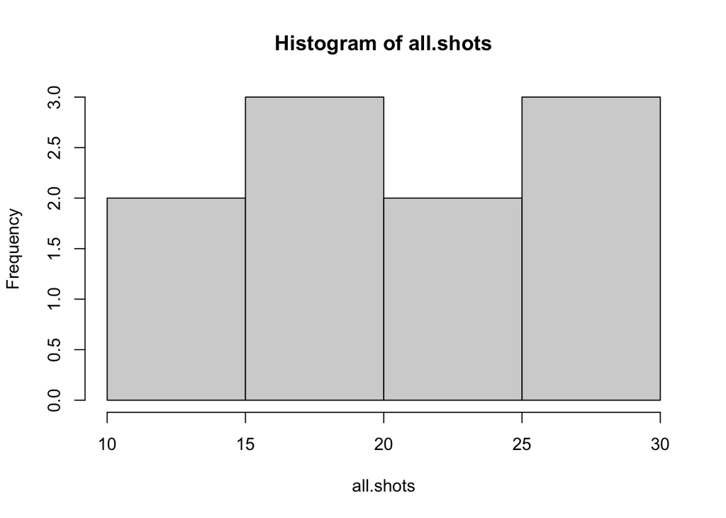

```r
hist(all.shots)
```

#### We want to determine both of their probabilities of making a shot. We can assume each round of 30 shots follows a binomial distribution.

#### This would be how to calculate the binomial likelihood.

```r
calc.log.lik=function(theta)
{
  all.log.liks=c()
  for (i in all.shots)
  {
    lik.theta1 = dbinom(x=i,
                        size = shots.each,
                        prob = theta[1],
                        log = TRUE)
    lik.theta2 = dbinom(x=i,
                        size = shots.each,
                        prob = theta[2],
                        log = TRUE)
    if(lik.theta1 > lik.theta2)
    {
      lik.log=lik.theta1
    }else if(lik.theta2 > lik.theta1)
    {
      lik.log=lik.theta2
    }
    all.log.liks=c(all.log.liks, lik.log)
  }
  log.lik.final=sum(all.log.liks)
  return(log.lik.final)
}
```

#### This is the needed MCMC code using the fmcmc package (Flexible MCMC)

```r
# load library
library(fmcmc)

# thetas initialization
theta=c(runif(1), runif(1))

# fmcmc command
ans <-
  MCMC(
    fun=calc.log.lik,
    initial = theta,
    nsteps = 1e5,
    kernel = kernel_unif_reflective(min. = -0.01, max. = 0.01, lb = 0, ub = 1),
    burnin = 40000
  )

# show answer
summary(ans)
```

```
##
## Iterations = 40001:1e+05
## Thinning interval = 1
## Number of chains = 1
## Sample size per chain = 60000
##
## 1. Empirical mean and standard deviation for each variable,
##    plus standard error of the mean:
##
##        Mean      SD  Naive SE Time-series SE
## par1 0.5305 0.04275 0.0001745       0.002750
## par2 0.8885 0.02595 0.0001060       0.001018
##
## 2. Quantiles for each variable:
##
##        2.5%    25%    50%    75%  97.5%
## par1 0.4465 0.5012 0.5313 0.5602 0.6117
## par2 0.8339 0.8716 0.8898 0.9068 0.9352
```

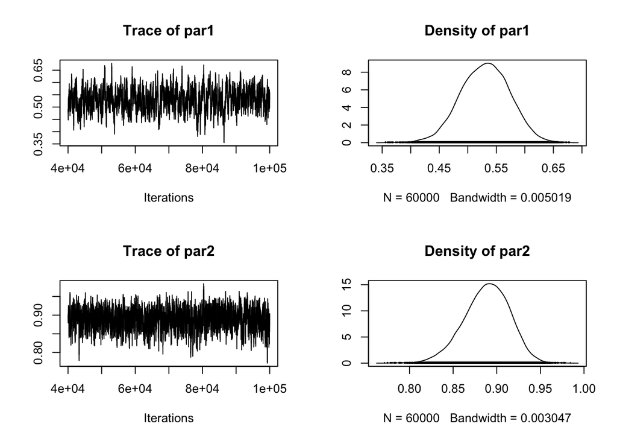

```r
# make plots
plot(ans)
```

### The true probabilities were 0.5 and 0.85. We can see MCMC did reasonably well! It helps that the players had different probabilities of making a shot. In cases where the shooters probabilitee are closer, we would need to collect more shots from the players and from more areas of the court to help improve our MCMC estimation. Lets show this in another example.

# Simulate another example with players with close probability

#### Since we need more data to estimate the probabilites correctly if they are close to each other, in this case, two basketball players chose their favorite 5 spots from the court (each) and shoot 300 (instead of 30) shots from each spot. Yes, I know, unrealistic, but let’s do the example anyway.

#### This is a distribution of how many shots they made from each spot

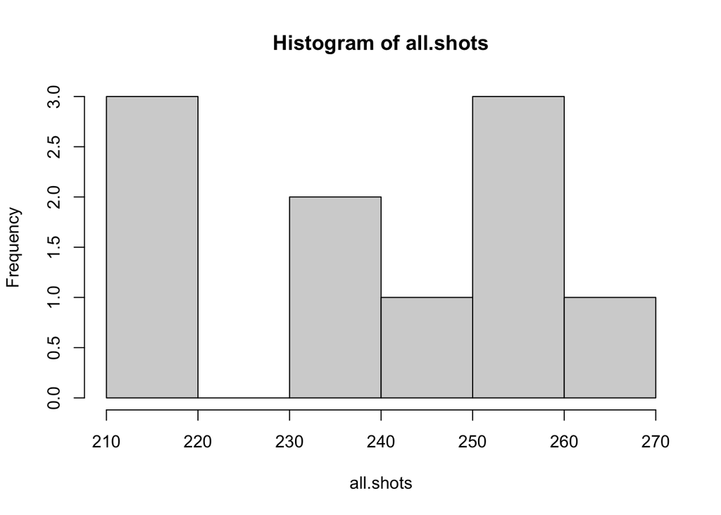

```r
hist(all.shots)
```

#### We can keep the same code as before, including the likelihood function

```r
# load library
library(fmcmc)

# thetas initialization
theta=c(runif(1), runif(1))

# fmcmc command
ans <-
  MCMC(
    fun=calc.log.lik,
    initial = theta,
    nsteps = 1e5,
    kernel = kernel_unif_reflective(min. = -0.01, max. = 0.01, lb = 0, ub = 1),
    burnin = 40000
  )

# show answer
summary(ans)
```

```
##
## Iterations = 40001:1e+05
## Thinning interval = 1
## Number of chains = 1
## Sample size per chain = 60000
##
## 1. Empirical mean and standard deviation for each variable,
##    plus standard error of the mean:
##
##        Mean      SD  Naive SE Time-series SE
## par1 0.8375 0.01023 4.176e-05      0.0001799
## par2 0.7370 0.01459 5.958e-05      0.0003611
##
## 2. Quantiles for each variable:
##
##        2.5%    25%    50%    75%  97.5%
## par1 0.8180 0.8306 0.8372 0.8441 0.8583
## par2 0.7082 0.7272 0.7369 0.7469 0.7655
```

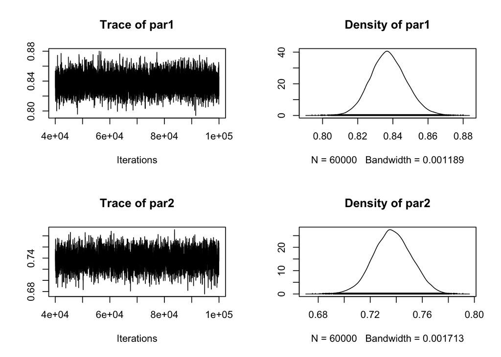

```r
# make plots
plot(ans)
```

### Clearly this is an unrealistic scenario. However, the message gets across. MCMC works very well to estimate parameters (including multiple parameter problems), the quality of the data is always most imporant and inspection of the trace and density plots should always be done to ensure a good fit. Other methods of MCMC quality control can be discussed later. This was only meant as a simple introduction into the method.